# Introduction to MorphoSim

This vignette aims to provide a general introduction to the functionality of MorphoSim input and output.

## Background

`MorphoSim` is an R package for simulating discrete morphological data under different extensions to the Mk model. It uses a tree object to simulate morphological transitions across phylogenetic trees with branches in evolutionary distance.

## Installing the package

`MorphoSim` is not yet available on CRAN but can be installed directly from from [GitHub](https://github.com/) using the package `devtools`

```r
# to install the package via GitHub
devtools::install_github("https://github.com/fossilsim/morphosim")

# load the package into the current working environment
library(MorphoSim)
```

## Quick Start

To simulate character data we first need a tree object to simulate along. Here we can simulate a timetree using the `TreeSim` r package as follows:

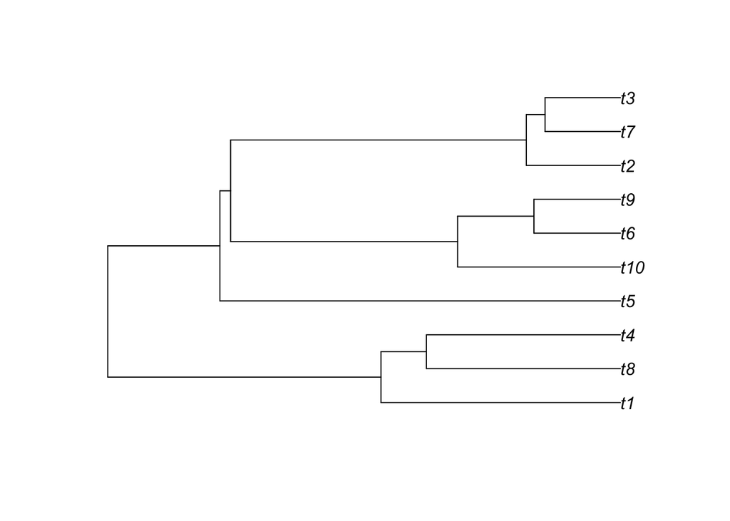

```r
# simulate a tree using TreeSim conditioned on tip number
tips = 10

# set a speciation rate
lambda = 0.1

# set an extinction rate
mu = 0.05

# simualte a birth death timetree
t = TreeSim::sim.bd.taxa(n = tips, numbsim = 1, lambda = lambda, mu = mu)[[1]]

plot(t)
```

Now that we have a timetree we can use the `MorphoSim::sim.morpho()` function to simulate character data. Note: Here we are using a timetree but the user can also provide trees with branch lengths in units of evolutionary distance. The following code simulates an Mk model with 2 character states.

```r
# define the tree to simulate character along
timetree = t

# if we provide a timetree we should specify the branch rate to convert it into a tree with branch lengths in evolution distance.
br.rates = 0.1

# specify the maximum character states to  simulate
k = 2

# specify the number of traits to simulate
trait.num = 20


transition_history <-  sim.morpho(time.tree = timetree,
                                  br.rates = br.rates,
                                  k = k,
                                  trait.num = trait.num,
                                  ancestral = TRUE)  # ancestral parameters specifies whether or not to return the character states at internal (ancestral) nodes.
```

We can plot the evolution of different traits along our tree using the `plot()` function:

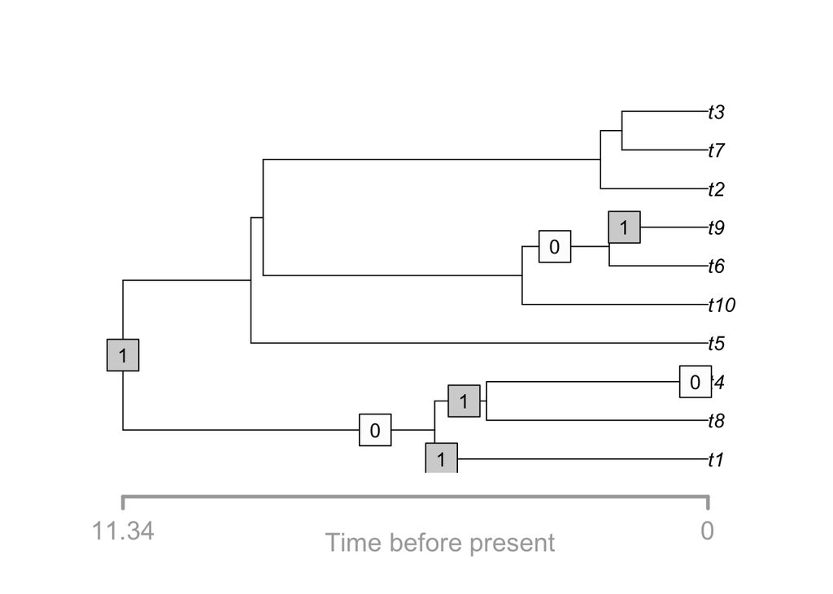

```r
plot(transition_history, trait = 1, timetree = T, br.rates = 0.1)
```

We can additionally plot the entire matrix using the function `MorphoSim::plotMorphoGrid`:

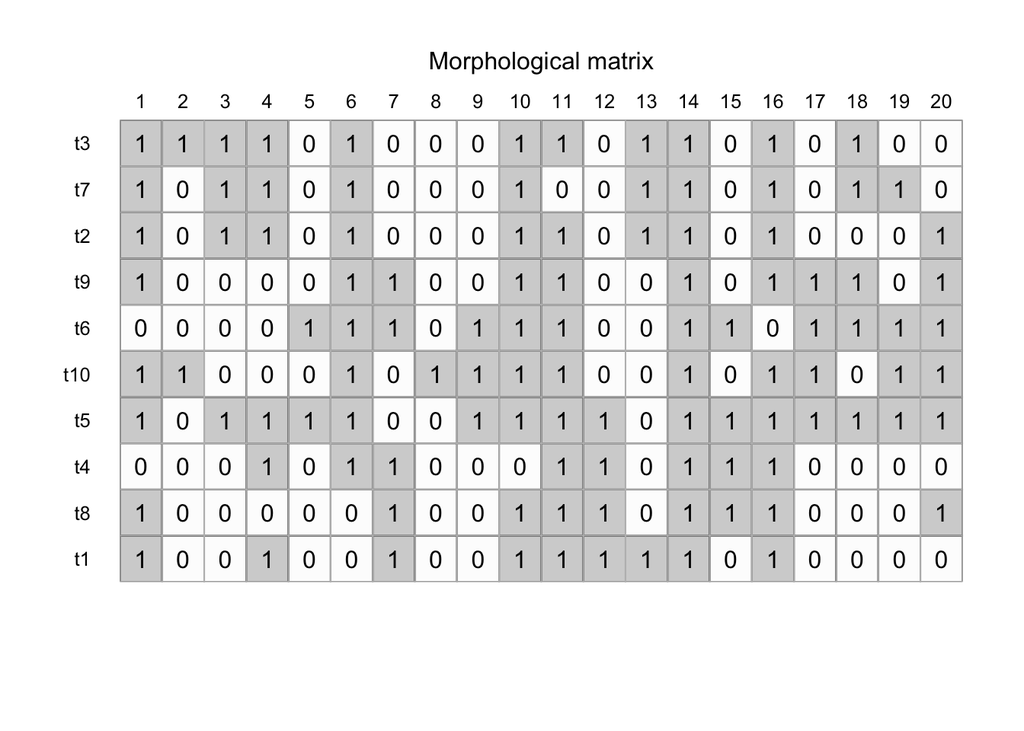

```r
MorphoSim::plotMorphoGrid(transition_history)
```

## Mk model extensions

In the code above we simulated an Mk model, however there a number of extensions to the original Mk model we might want to simualte.

### Simualting acertainment bias

In morphological datasets it is common for all traits to be varying, a characteristic which differs from that of molecular data. As such Lewis described an MkV model which accounts for this characteristic. To simulate datasets under an Mk model we need to set the `variable` parameter to `TRUE`. This is `FALSE` by default.

```r
transition_history <-  sim.morpho(time.tree = timetree,
                                  br.rates = br.rates,
                                  k = k,
                                  trait.num = trait.num,
                                  ancestral = TRUE,
                                  variable = TRUE)
```

If you use the `MorphoSim::plotMorphoGrid` now, you will see that all of the traits in your matrix are varying across taxa.

### Simualting among character rate variation

It is common to use models which allow rates to vary across characters according to rates drawn from a discritised gamma distribution. To simulate characters with among character rate variation (ACRV) use the following code

```r
transition_history <-  sim.morpho(time.tree = timetree,
                                  br.rates = br.rates,
                                  k = k,
                                  trait.num = trait.num,
                                  ancestral = TRUE,
                                  variable = TRUE,
                                  ACRV = "gamma",
                                  ncats.gamma = 4, # this value is the default
                                  alpha.gamma = 1) # this value is the default
```

If we look at our matrix now we can see information about under which rate category each trait was simualted. Here we take 1 as the lowest rate.

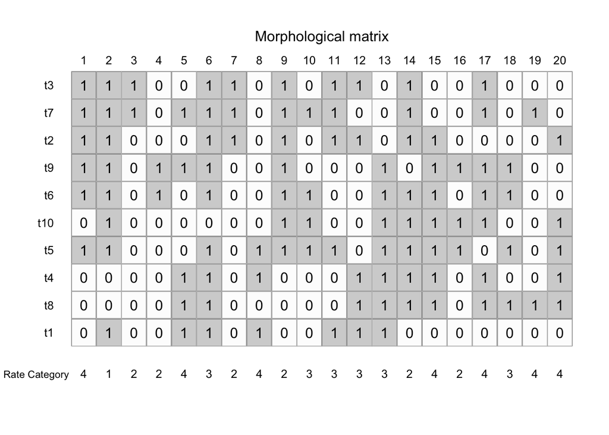

```r
MorphoSim::plotMorphoGrid(transition_history)
```

If we plot the different traits along our tree can we see more transitions across traits with higher rates?

### Asymmetric Q matrices

The Mk model assumes a symmetric Q matrix, that is, the probability of transitioning from a “0” to a “1” for example, is the same as transitioning to a “2”. This assumption is strict and may not hold for a number of empirical datasets. As such we can use asymmetric Q matrices which can allow for different probabilities depending on the current state.

Here we show an example using an ordered Q matrix. This commonly applied asymmetric Q matrix allow the user to explicitly specify the order or transitions between states. This example says that a “0” can transition to a “1” but not a “2”, a “1” can transition to either a “0” or a “2”, and a “2” can only transition to a “1”.

```r
#define an ordered Q matrix

ord_Q <- matrix(c(
-0.5, 0.5, 0.0,
0.3333333, -0.6666667, 0.3333333,
0.0, 0.5, -0.5
), nrow = 3, byrow = TRUE)

transition_history <-  sim.morpho(time.tree = timetree,
                                  br.rates = br.rates,
                                  k = 3,
                                  trait.num = trait.num,
                                  ancestral = TRUE,
                                  variable = TRUE,
                                  ACRV = "gamma",
                                  define_Q = ord_Q)
```

### Simulate different partitions

We may want to simulate datasets which have different partitions (groups of traits) that have different number of states. To do this we need to specify the number of states in each partition and the number of traits per partition.

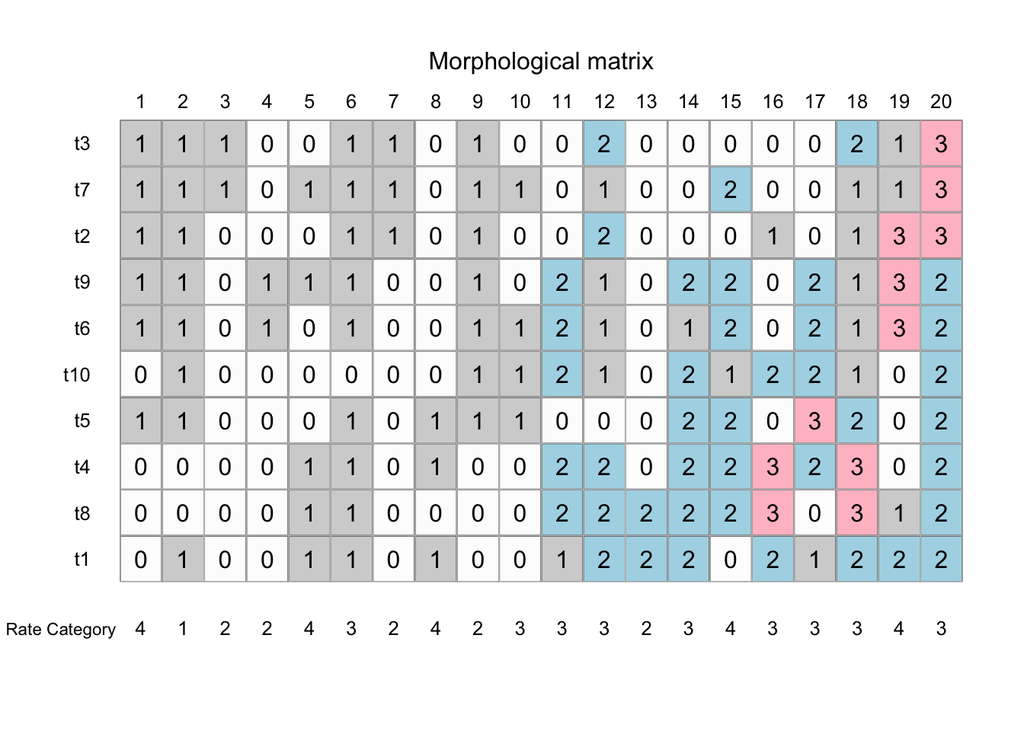

```r
transition_history <-  sim.morpho(time.tree = timetree,
                                  br.rates = br.rates,
                                  k = c(2,3,4),
                                  partition = c(10,5,5), # the sum of partitions must equal trait.num
                                  trait.num = trait.num,
                                  ancestral = TRUE,
                                  variable = TRUE,
                                  ACRV = "gamma")

MorphoSim::plotMorphoGrid(transition_history)
```

We now have 4 states in our morphological matrix.

**Note:** If you use a user specified Q matrix you can only simulate a single partition. The number of traits should be specified using trait.num in this case. Ensure that k is still correct for your defined Q matrix.

We can get information about the model we used to simulate a morpho object using

```r
transition_history$model
```

```
## [1] "MkgammaV_Part:10states:2" "MkgammaV_Part:5states:3"
## [3] "MkgammaV_Part:5states:4"
```

This states that we have simulated data under an MkV + Gamma model, with 3 partitions, the first with 10 traits and maximum 2 states, the 5 traits and maximum 3 states and the last partition with 5 traits and maximum 4 states.

## Missing data

In palaeontological datasets it is quite common that there will be a degree of missing data within our matrix. This is a result of taphonomic process which act to degrade specimens in the fossil record. To better understand the impact of missing data on a phylogenetic inference we need to be able to simulate it. `MorphoSim` shiny provides a function to remove data according different methods at user probabilities.

We can remove data according to 4 different methods, “random”, “rate”, “trait”, and “partition”.

```r
## remove data randomly across the entire matrix
missing.data <- sim.missing.data(data = transition_history,
                                  method = "random",
                                  probability = 0.5)

# remove data based on the rate it was simulated under
missing.data <- sim.missing.data(data = transition_history,
                                        method = "rate",
                                        probability = c(0,0,0.2,1)) # ensure this value equals the number of rate categories

# remove specific characters from specific traits
missing.data <- sim.missing.data(data = transition_history,
                                 method = "trait",
                                 probability = 0.8,
                                 traits = c(1,2,5))

# remove data based on the partition
missing.data <- sim.missing.data(data = transition_history,
                                 method = "partition",
                                 probability = c(0.5, 0, 1)) # ensure this value equals the number of partitions
```

Now if we look at our matrix we can see that we have lost a lot of information

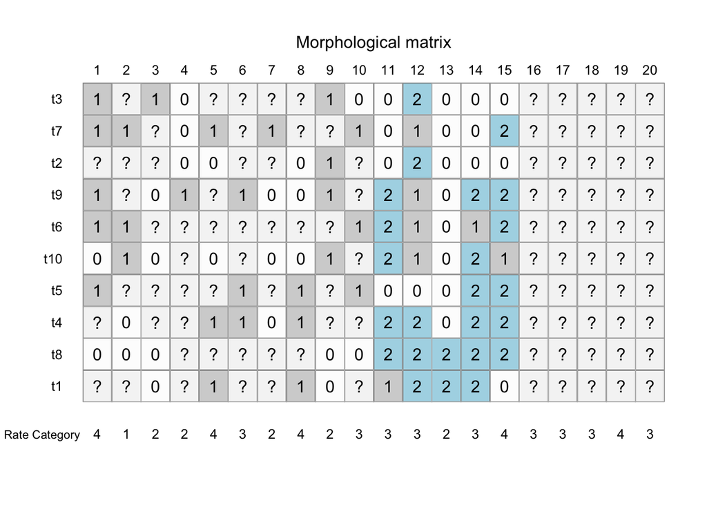

```r
MorphoSim::plotMorphoGrid(missing.data)
```